# Análise 3: Autismo e Enxaqueca: Uma Associação Inexplorada

Jânice Roberta de Paula

2025-12-29

## Introdução

Neste artigo, o autor faz uma revisão de três autores, sobre o risco aumentado de enxaquecas em pessoas dentro do Transtorno do Espectro Autista. São os autores: Underwood et al., 2019; Victorio, 2014; Sullivan et al., 2014.

Ele inicia seu artigo discorrendo quais são os critérios para o diagnóstico do TEA, de acordo com o DSM-5 e em seguida, quais são os critérios de diagnóstico da enxaqueca (com e sem aura), a partir do ICHD-3.

## Objetivos

Esta revisão narrativa avalia a evidência da literatura científica sobre a co-ocorrência entre TEA e enxaqueca na esperança de lançar alguma luz sobre esta associação pouco explorada. O objetivo central dessa revisão é delinear melhor os principais resultados de pesquisa de última geração sobre a comorbidade entre TEA e enxaqueca sugerindo os possíveis mecanismos fisiopatológicos relacionados e avaliando se pacientes com TEA são vulneráveis ao sub-reconhecimento e subtratamento da enxaqueca.

## Métodos

Revisão de vários artigos publicados ao longo dos anos, através da realização de uma pesquisa usando a seguinte sintaxe “autismo” (Título/Resumo) OU “Asperger” (Título/Resumo) OU “transtornos invasivos do desenvolvimento” (Título/Resumo) E “enxaqueca” (Título/Resumo). Foram identificadas referências por meio de busca eletrônica de banco de dados no CENTRAL, Ovid MEDLINE, Embase, PsycINFO.

## Resultados

O autismo e a enxaqueca compartilham alterações fisiopatológicas comuns: desregulação da neurotransmissão, especialmente do sistema serotoninérgico; resposta imune alterada causando neuroinflamação neurogênica; achados anormais especialmente na organização do minicoluna cortical e no eixo intestino-cérebro disfuncional; genes de suscetibilidade compartilhados.

Estudos de Comorbidade de Enxaqueca em Autismo (TEA)

| Estudo | Amostra de TEA | Taxa de Enxaqueca (%) | Outras Descobertas |
| --- | --- | --- | --- |
| Underwood et al., 2019 [21] | 105 adultos (76 controles saudáveis) sem deficiência intelectual | 42,7% (vs. 20,5% dos controles) | Alta taxa (89,5%) de comorbidades psiquiátricas (depressão 62,9%; ansiedade 55,2%) |
| Victorio, 2014 [22] | 18 crianças | 61% | 44% sem aura; 5,6% com aura e 11% ambos os tipos |
| Sullivan et al., 2014 [23] | 81 crianças | 28,4% | Ansiedade mais generalizada e hiperreatividade sensorial |

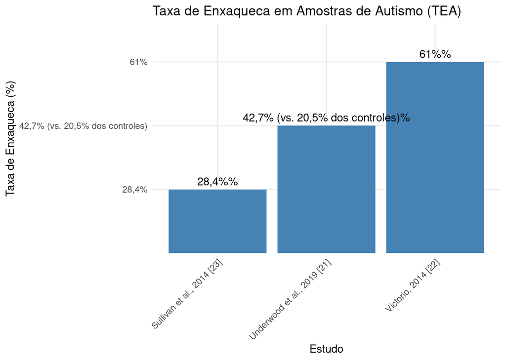

## Conclusão

Mesmo que o autismo e a enxaqueca sejam duas condições neurológicas comuns, apenas alguns estudos investigam sua comorbidade. Esses estudos, apesar de uma pequena amostra de pacientes com autismo, indicam uma alta taxa de sintomatologia enxaqueca. Indivíduos com autismo freqüentemente têm uma sensibilidade à dor alterada que pode distorcer sua percepção de dores de cabeça. Além disso, a dimensão social da dor pode ser prejudicada em pessoas com autismo com consequências imprevisíveis em relatos de dor. Em relação à comorbidade entre autismo e enxaqueca, parece claro que mais estudos epidemiológicos são necessários para levar em conta a verdadeira escala dessa associação pouco explorada.